## Predicting with Machine Learning

#### Classification: How well was an excerise with dumbells done?

*Practical Machine Learning Course Project, Andrea Heide, March 3rd, 2017*

### Executive Summary

The goal of this machine learning course project is to predict how well 6 participants performed barbell lifts, based on data collected from accelerometers on the belt, forearm, arm, and dumbell of the participants. They performed the barbell lifts correctly and incorrectly in 5 different ways, classified as follows:  
* class A - exactly according to the specification,  
* class B - throwing the elbows to the front,  
* class C - lifting the dumbbell only halfway,  
* class D - lowering the dumbbell only halfway and  
* class E - throwing the hips to the front.  
To model the outcome (variable classe), a random forest algorihtm with 10-fold cross validation was used which achieved a 99% accuracy on the validation set. The 20 test cases were predicted correctly with this model and a svm model for comparison. Both models achieved 100% accuracy on the test set.

*Source of the data: Velloso, E.; Bulling, A.; Gellersen, H.; Ugulino, W.; Fuks, H.: Qualitative Activity Recognition of Weight Lifting Exercises. Proceedings of 4th International Conference in Cooperation with SIGCHI (Augmented Human ’13) . Stuttgart, Germany: ACM SIGCHI, 2013.*

### Loading the nescessary libraries

```r
library(caret)
library(rpart)
library(rattle)
library(parallel)
library(doParallel)
library(e1071)
```

### Loading the data

```r
## training set
file_url <- "https://d396qusza40orc.cloudfront.net/predmachlearn/pml-training.csv"
download.file(file_url, destfile = "./pml-training.csv", method = "curl")
training <- read.csv("./pml-training.csv")
## testing set
file_url <- "https://d396qusza40orc.cloudfront.net/predmachlearn/pml-testing.csv"
download.file(file_url, destfile = "./pml-testing.csv", method = "curl")
testing <- read.csv("./pml-testing.csv")
```

### Some pre-processing of the data

```r
## remove columns that are not relevant
train1 <- training[, -(1:7)]
test1 <- testing[, -(1:7)]
## remove columns with more than 50% NA values
train2 <- train1[, -which(colMeans(is.na(train1)) > 0.5)]
test2 <- test1[, -which(colMeans(is.na(train1)) > 0.5)]
## remove columns with just the same value using the caret function nearZeroVar
train3 <- train2[, - (nearZeroVar(train2))]
test <- test2[, - (nearZeroVar(train2))]
```

### Splitting the data into training and validation set

We have many variables and can assume complex relationships. To be able to explore and validate several prediction models, I split the training data into a training (75% of the data) and a validation set (25% of the data).

```r
set.seed(3312)
inTrain=createDataPartition(train3$classe,p=0.75)[[1]]
train=train3[ inTrain,]
val=train3[-inTrain,]
```

The training set contains 14.718 records of 53 variables, the validation set contains 4.904 records. The test set contains 20 records of 53 variables. An overview over the variables is given here:

```r
str(train)
```

```
## 'data.frame':    14718 obs. of  53 variables:
##  $ roll_belt           : num  1.41 1.41 1.42 1.48 1.45 1.42 1.42 1.43 1.45 1.43 ...
##  $ pitch_belt          : num  8.07 8.07 8.07 8.07 8.06 8.09 8.13 8.16 8.17 8.18 ...
##  $ yaw_belt            : num  -94.4 -94.4 -94.4 -94.4 -94.4 -94.4 -94.4 -94.4 -94.4 -94.4 ...
##  $ total_accel_belt    : int  3 3 3 3 3 3 3 3 3 3 ...
##  $ gyros_belt_x        : num  0 0.02 0 0.02 0.02 0.02 0.02 0.02 0.03 0.02 ...
##  $ gyros_belt_y        : num  0 0 0 0.02 0 0 0 0 0 0 ...
##  $ gyros_belt_z        : num  -0.02 -0.02 -0.02 -0.02 -0.02 -0.02 -0.02 -0.02 0 -0.02 ...
##  $ accel_belt_x        : int  -21 -22 -20 -21 -21 -22 -22 -20 -21 -22 ...
##  $ accel_belt_y        : int  4 4 5 2 4 3 4 2 4 2 ...
##  $ accel_belt_z        : int  22 22 23 24 21 21 21 24 22 23 ...
##  $ magnet_belt_x       : int  -3 -7 -2 -6 0 -4 -2 1 -3 -2 ...
##  $ magnet_belt_y       : int  599 608 600 600 603 599 603 602 609 602 ...
##  $ magnet_belt_z       : int  -313 -311 -305 -302 -312 -311 -313 -312 -308 -319 ...
##  $ roll_arm            : num  -128 -128 -128 -128 -128 -128 -128 -128 -128 -128 ...
```

[output cut: 39 more lines]

### Choosing the modelling algorithm

As the computations took a long time, I used the very valueable information on parallel processing provided by Len Greski in the course forum; I also followed his example to use 10-fold cross validation:

```r
cluster <- makeCluster(detectCores() - 1) # convention to leave 1 core for OS
registerDoParallel(cluster)
```

Manually set a fit control with 10-fold cross-validation and parallel processing:

```r
fitControl <- trainControl(method = "cv", number = 10, allowParallel = TRUE)
```

To get a first impression, I fitted a tree model with rpart. The resulting decision tree is plotted below. However, the accuracy was about 0.5 and therefore very low.

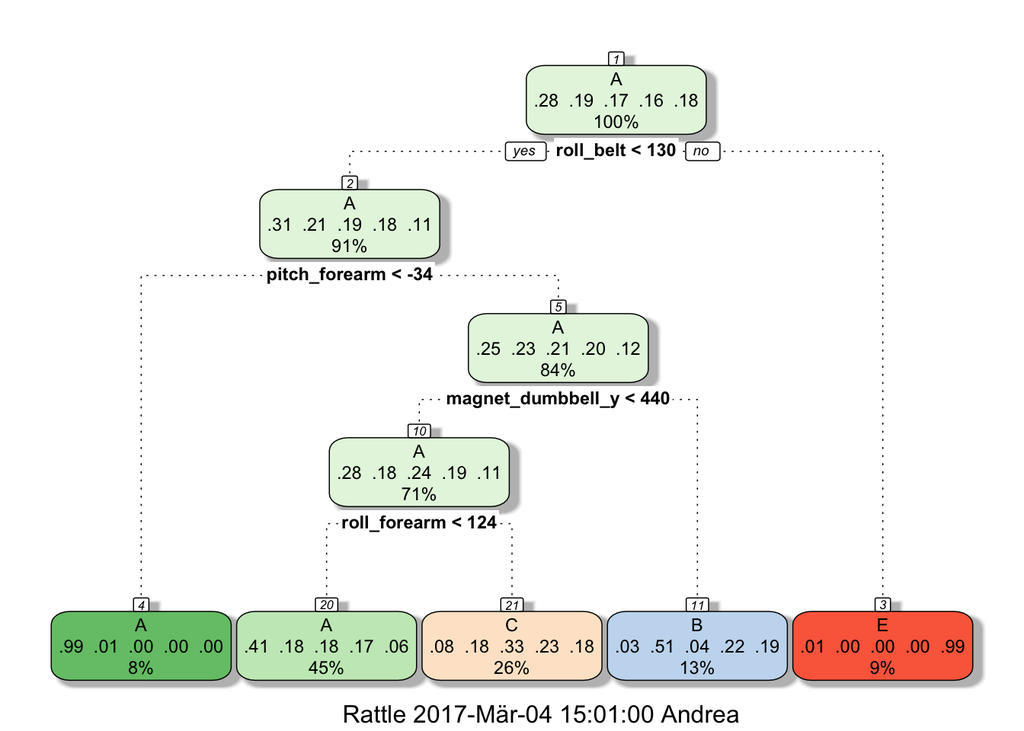

```r
## model
modFit_rpart <- train(classe ~., method="rpart", data=train, trControl = fitControl)
fancyRpartPlot(modFit_rpart$finalModel)
```

```r
print(modFit_rpart)
```

```
## CART
##
## 14718 samples
##    52 predictor
##     5 classes: 'A', 'B', 'C', 'D', 'E'
##
## No pre-processing
## Resampling: Cross-Validated (10 fold)
## Summary of sample sizes: 13246, 13244, 13247, 13248, 13246, 13245, ...
## Resampling results across tuning parameters:
##
##   cp          Accuracy   Kappa
##   0.03636191  0.5085636  0.35787646
##   0.05984367  0.4421087  0.25188917
##   0.11734549  0.3247771  0.06155238
##
## Accuracy was used to select the optimal model using  the largest value.
## The final value used for the model was cp = 0.03636191.
```

```r
## accuracy
pred_rpart <- predict(modFit_rpart, newdata = val)
confusionMatrix(pred_rpart, val$classe)
```

```
## Confusion Matrix and Statistics
##
##           Reference
## Prediction    A    B    C    D    E
##          A 1271  396  390  349  132
##          B   20  321   32  149  126
##          C  100  232  433  306  258
##          D    0    0    0    0    0
##          E    4    0    0    0  385
##
## Overall Statistics
##
##                Accuracy : 0.4914
##                  95% CI : (0.4774, 0.5055)
##     No Information Rate : 0.2845
##     P-Value [Acc > NIR] : < 2.2e-16
##
##                   Kappa : 0.3355
##  Mcnemar's Test P-Value : NA
##
## Statistics by Class:
##
##                      Class: A Class: B Class: C Class: D Class: E
## Sensitivity            0.9111  0.33825   0.5064   0.0000  0.42730
## Specificity            0.6389  0.91732   0.7787   1.0000  0.99900
## Pos Pred Value         0.5008  0.49537   0.3258      NaN  0.98972
## Neg Pred Value         0.9476  0.85244   0.8820   0.8361  0.88571
## Prevalence             0.2845  0.19352   0.1743   0.1639  0.18373
## Detection Rate         0.2592  0.06546   0.0883   0.0000  0.07851
## Detection Prevalence   0.5175  0.13214   0.2710   0.0000  0.07932
## Balanced Accuracy      0.7750  0.62779   0.6426   0.5000  0.71315
```

I then also tried pca pre processing to use only the most influential variables (explaining 80% of the outcome) to save computing time for the following steps.

```r
pcaObj <- preProcess(train, method = "pca", thresh = 0.8)
train_pca <- predict(pcaObj, train)
val_pca <- predict(pcaObj, val)
test_pca <- predict(pcaObj, test)
```

We want to model a factor outcome using a large number of variables/predictors. In the Practical Machine Learning quiz no. 4, random forest performed well for such a task. Also, I read that Microsoft uses random forest for the Kinect - a setting that might be similar to the classification problem of this project. Random forest is supposed to have great predicive power, with the downside of being a ‘black box’, not very intuitive. As our goal is to come up with the best possible prediction, I chose random forest, but also tried svm as a possible alternative in comparison. If more computing power or time was available, I also would have tried boosting with “gbm” and stacking the prediction models, as in quiz no. 4.

Fit the model with the desired random forest algorithm, using the defined control parameters, with and without pca:

```r
## model with pca
modFit_rf_pca <- train(classe ~., method="rf", data=train_pca, trControl = fitControl)
print(modFit_rf_pca)
```

```
## Random Forest
##
## 14718 samples
##    12 predictor
##     5 classes: 'A', 'B', 'C', 'D', 'E'
##
## No pre-processing
## Resampling: Cross-Validated (10 fold)
## Summary of sample sizes: 13246, 13245, 13246, 13246, 13246, 13247, ...
## Resampling results across tuning parameters:
##
##   mtry  Accuracy   Kappa
##    2    0.9580097  0.9468814
##    7    0.9525066  0.9399247
##   12    0.9442858  0.9295267
##
## Accuracy was used to select the optimal model using  the largest value.
## The final value used for the model was mtry = 2.
```

```r
## model without pca
modFit_rf <- train(classe ~., method="rf", data=train, trControl = fitControl)
print(modFit_rf)
```

```
## Random Forest
##
## 14718 samples
##    52 predictor
##     5 classes: 'A', 'B', 'C', 'D', 'E'
##
## No pre-processing
## Resampling: Cross-Validated (10 fold)
## Summary of sample sizes: 13246, 13246, 13246, 13245, 13246, 13247, ...
## Resampling results across tuning parameters:
##
##   mtry  Accuracy   Kappa
##    2    0.9921192  0.9900299
##   27    0.9932061  0.9914053
##   52    0.9855963  0.9817782
##
## Accuracy was used to select the optimal model using  the largest value.
## The final value used for the model was mtry = 27.
```

Accuracy:

```r
## prediction with pca
pred_rf_pca <- predict(modFit_rf_pca, newdata = val_pca)
confusionMatrix(pred_rf_pca, val_pca$classe)
```

```
## Confusion Matrix and Statistics
##
##           Reference
## Prediction    A    B    C    D    E
##          A 1362   20   17   10    0
##          B    9  902    9    4    7
##          C   15   22  817   24    4
##          D    7    3    6  765    6
##          E    2    2    6    1  884
##
## Overall Statistics
##
##                Accuracy : 0.9645
##                  95% CI : (0.959, 0.9695)
##     No Information Rate : 0.2845
##     P-Value [Acc > NIR] : < 2.2e-16
##
##                   Kappa : 0.9551
##  Mcnemar's Test P-Value : 0.0008662
##
## Statistics by Class:
##
##                      Class: A Class: B Class: C Class: D Class: E
## Sensitivity            0.9763   0.9505   0.9556   0.9515   0.9811
## Specificity            0.9866   0.9927   0.9839   0.9946   0.9973
## Pos Pred Value         0.9666   0.9689   0.9263   0.9720   0.9877
## Neg Pred Value         0.9906   0.9882   0.9906   0.9905   0.9958
## Prevalence             0.2845   0.1935   0.1743   0.1639   0.1837
## Detection Rate         0.2777   0.1839   0.1666   0.1560   0.1803
## Detection Prevalence   0.2873   0.1898   0.1799   0.1605   0.1825
## Balanced Accuracy      0.9815   0.9716   0.9698   0.9731   0.9892
```

```r
## prediction without pca
pred_rf <- predict(modFit_rf, newdata = val)
confusionMatrix(pred_rf, val$classe)
```

```
## Confusion Matrix and Statistics
##
##           Reference
## Prediction    A    B    C    D    E
##          A 1394    3    0    0    0
##          B    1  940    2    0    0
##          C    0    6  846    8    2
##          D    0    0    7  796    5
##          E    0    0    0    0  894
##
## Overall Statistics
##
##                Accuracy : 0.9931
##                  95% CI : (0.9903, 0.9952)
##     No Information Rate : 0.2845
##     P-Value [Acc > NIR] : < 2.2e-16
##
##                   Kappa : 0.9912
##  Mcnemar's Test P-Value : NA
##
## Statistics by Class:
##
##                      Class: A Class: B Class: C Class: D Class: E
## Sensitivity            0.9993   0.9905   0.9895   0.9900   0.9922
## Specificity            0.9991   0.9992   0.9960   0.9971   1.0000
## Pos Pred Value         0.9979   0.9968   0.9814   0.9851   1.0000
## Neg Pred Value         0.9997   0.9977   0.9978   0.9980   0.9983
## Prevalence             0.2845   0.1935   0.1743   0.1639   0.1837
## Detection Rate         0.2843   0.1917   0.1725   0.1623   0.1823
## Detection Prevalence   0.2849   0.1923   0.1758   0.1648   0.1823
## Balanced Accuracy      0.9992   0.9949   0.9928   0.9936   0.9961
```

As an alternative algorithm that might be fit to the task, I tried a support vector machine algorithm svm (as in quiz 4), again with and without pca:

```r
## model with pca
modFit_svm_pca <- svm(classe ~., data=train_pca, trControl = fitControl)
print(modFit_svm_pca)
```

```
##
## Call:
## svm(formula = classe ~ ., data = train_pca, trControl = fitControl)
##
##
## Parameters:
##    SVM-Type:  C-classification
##  SVM-Kernel:  radial
##        cost:  1
##       gamma:  0.08333333
##
## Number of Support Vectors:  8665
```

```r
## model without pca
modFit_svm <- svm(classe ~., data=train, trControl = fitControl)
print(modFit_svm)
```

```
##
## Call:
## svm(formula = classe ~ ., data = train, trControl = fitControl)
##
##
## Parameters:
##    SVM-Type:  C-classification
##  SVM-Kernel:  radial
##        cost:  1
##       gamma:  0.01923077
##
## Number of Support Vectors:  6791
```

Accuracy:

```r
## prediction with pca
pred_svm_pca <- predict(modFit_svm_pca, newdata = val_pca)
confusionMatrix(pred_svm_pca, val_pca$classe)
```

```
## Confusion Matrix and Statistics
##
##           Reference
## Prediction    A    B    C    D    E
##          A 1278   98   52   33   19
##          B   34  747   55   11   30
##          C   47   79  724   73   48
##          D   24   19   18  677   44
##          E   12    6    6   10  760
##
## Overall Statistics
##
##                Accuracy : 0.8536
##                  95% CI : (0.8434, 0.8634)
##     No Information Rate : 0.2845
##     P-Value [Acc > NIR] : < 2.2e-16
##
##                   Kappa : 0.8145
##  Mcnemar's Test P-Value : < 2.2e-16
##
## Statistics by Class:
##
##                      Class: A Class: B Class: C Class: D Class: E
## Sensitivity            0.9161   0.7871   0.8468   0.8420   0.8435
## Specificity            0.9424   0.9671   0.9390   0.9744   0.9915
## Pos Pred Value         0.8635   0.8518   0.7456   0.8657   0.9572
## Neg Pred Value         0.9658   0.9498   0.9667   0.9692   0.9657
## Prevalence             0.2845   0.1935   0.1743   0.1639   0.1837
## Detection Rate         0.2606   0.1523   0.1476   0.1381   0.1550
## Detection Prevalence   0.3018   0.1788   0.1980   0.1595   0.1619
## Balanced Accuracy      0.9293   0.8771   0.8929   0.9082   0.9175
```

```r
## prediction without pca
pred_svm <- predict(modFit_svm, newdata = val)
confusionMatrix(pred_svm, val$classe)
```

```
## Confusion Matrix and Statistics
##
##           Reference
## Prediction    A    B    C    D    E
##          A 1385   66    1    1    0
##          B    3  858   31    0    8
##          C    6   24  818   70   23
##          D    0    1    5  732   27
##          E    1    0    0    1  843
##
## Overall Statistics
##
##                Accuracy : 0.9454
##                  95% CI : (0.9386, 0.9515)
##     No Information Rate : 0.2845
##     P-Value [Acc > NIR] : < 2.2e-16
##
##                   Kappa : 0.9308
##  Mcnemar's Test P-Value : < 2.2e-16
##
## Statistics by Class:
##
##                      Class: A Class: B Class: C Class: D Class: E
## Sensitivity            0.9928   0.9041   0.9567   0.9104   0.9356
## Specificity            0.9806   0.9894   0.9696   0.9920   0.9995
## Pos Pred Value         0.9532   0.9533   0.8693   0.9569   0.9976
## Neg Pred Value         0.9971   0.9773   0.9907   0.9826   0.9857
## Prevalence             0.2845   0.1935   0.1743   0.1639   0.1837
## Detection Rate         0.2824   0.1750   0.1668   0.1493   0.1719
## Detection Prevalence   0.2963   0.1835   0.1919   0.1560   0.1723
## Balanced Accuracy      0.9867   0.9467   0.9632   0.9512   0.9676
```

## Expected out-of-sample error

| Model | Accuracy | Out of sample error |
| --- | --- | --- |
| rpart | 0.49 | 0.51 |
| rf with pca | 0.96 | 0.04 |
| rf | 0.99 | 0.01 |
| svm with pca | 0.85 | 0.15 |
| svm | 0.94 | 0.06 |

As expected, the random forest model without pca has the best accuracy / smallest out-of-sample error.

### Prediction against the test set

I made the prediction against the test set both with the random forest model and with the svm model. The results for both calculations were identical and achieved a 100% score on the quiz.

```r
## prediction with rf
pred_final_rf <- predict(modFit_rf, newdata = test)
## prediction with svm
pred_final_svm <- predict(modFit_svm, newdata = test)
## overview results
predicted_cases <- data.frame(pred_final_rf)
predicted_cases <- cbind(predicted_cases, pred_final_svm)
predicted_cases
```

```
##    pred_final_rf pred_final_svm
## 1              B              B
## 2              A              A
## 3              B              B
## 4              A              A
## 5              A              A
## 6              E              E
## 7              D              D
## 8              B              B
## 9              A              A
## 10             A              A
## 11             B              B
## 12             C              C
## 13             B              B
## 14             A              A
## 15             E              E
## 16             E              E
## 17             A              A
## 18             B              B
## 19             B              B
## 20             B              B
```